## Analyse des données Licence Pro 2025-2026

### Cours n°1- Les données en statistique

#### Florian Bayer

### Objectifs du cours

Savoir caractériser et organiser les données est une étape essentielle de toute étude scientifique. Outre la méthode de représentation graphique, le type de données est très important en statistique :

les **méthodes** ne seront pas les mêmes pour - **caractériser** le prénom le plus fréquemment données en 2019 - ou pour déterminer l'âge moyen de la population française.

Les objectifs de ce cours sont donc :

- de réviser le **vocabulaire** portant sur les données en cartographie et en statistique
- d'apprendre à **reconnaître** les différents types de données et de tableaux

### L'information géographique

Le géographe a pour particularité de s'intéresser aux **lieux** auxquels sont rattachés les données.

- Une information non localisable a donc peu d'intérêt pour le géographe

Le cartographe utilise donc de l'**information géographique**, c'est-à-dire localisable dans l'espace :

- Par des coordonnées
- Par une appartenance à un lieu, à un maillage

Ces appartenances ont un intérêt si elles peuvent être **caractériser** :

- À une commune peut être associée sa population totale ou sa densité

Si la collecte de l'information géographique peut parfois être laborieuse, son analyse peut se faire avec les mêmes outils qu'en statistique.

### Les données en cartographie

Les données utilisées en cartographie et statistique proviennent de multiples sources (*recensement, sondage,images satellites etc.*) et peuvent être **caractérisées** (première partie du cours) :

**Données qualitatives**

**Données quantitatives**

[figure not shown]

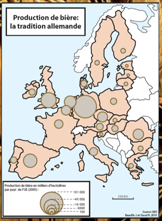

### Les données en cartographie

Les données peuvent être récupérées sous forme de tableaux (*i.e. INSEE*), ou bien issues de différentes sources (livres, articles, pixels).

Il est nécessaire de **restructurer** ces données, le plus souvent sous la forme d'un nouveau tableau. Les différents types de tableaux seront abordés dans la seconde partie du cours.

### 1- Les données en cartographie

### Rappels de vocabulaire : statistique

Avant de définir les grands types de données, il est nécessaire de rappeler le vocabulaire commun aux données

**La statistique** : l'ensemble de techniques et d'outils mathématiques permettant d'analyser des données

« L'objet de la méthode statistique est la réduction des données. Une masse de données doit être remplacée par un petit nombre de quantités représentant correctement cette masse, et contenant autant que possible la totalité de l'information pertinente contenue dans les données d'origine. » - Sir Ronald Aymler Fisher

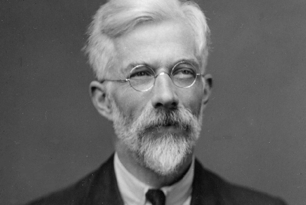

**Les statistiques** : les données textes ou chiffres (alphanumériques) décrivant une population, un ensemble

### Rappels de vocabulaire : population

La **population** ou **l'ensemble** :

- La collection (l'ensemble) des données qui vont servir à créer votre carte.
- En géographie cet ensemble est très rarement infini
- On parlera souvent de série statistique pour les données quantitatives

Ensemble des unités statistiques étudiées : les pays européens

Mais la population peut aussi correspondre à des personnes

[figure not shown]

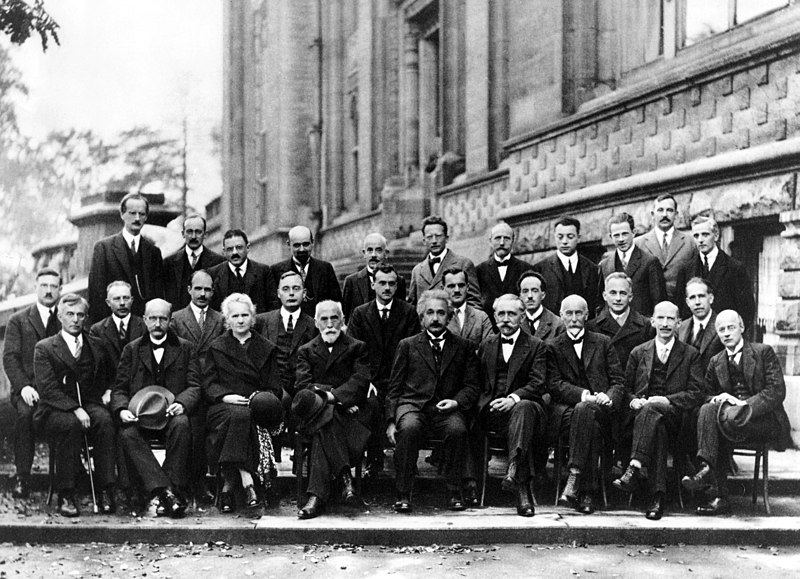

### Rappels de vocabulaire : élément

L'**élément** ou l'individu : un objet constitutif de l'ensemble

La Belgique est un élément de l'ensemble des pays européens

Marie Curie est un individu de l'ensemble des participants du Congrès de Solvay

| iso_a3 | Nom | Continent |
| --- | --- | --- |
| AUT | Austria | Europe |
| BEL | Belgium | Europe |
| **BEL** | **Belgium** | **Europe** |
| BGR | Bulgaria | Europe |
| CYP | Cyprus | Europe |

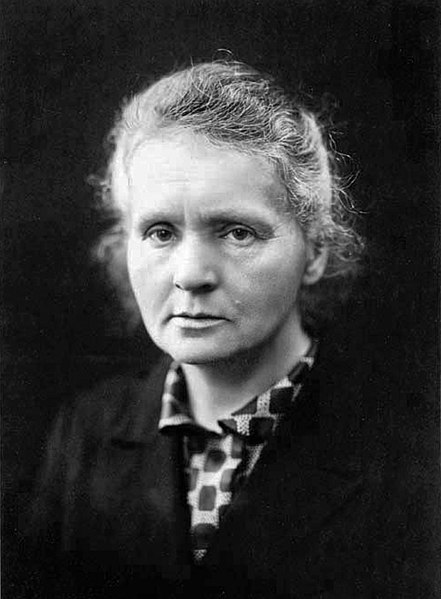

### Rappels de vocabulaire : caractère

Le **caractère** : les éléments d'un ensemble sont décrits par un caractère.

Chaque pays peut-être caractérisé par son code, son nom, sa superficie, sa population

De même que des personnes (Nom, prénom, age, sexe, adresse etc.)

| iso_a3 | Nom | Continent | Superficie | Population |
| --- | --- | --- | --- | --- |

| Nom | Prénom | Sexe | Adresse |
| --- | --- | --- | --- |

### Rappels de vocabulaire : modalité / valeur

La **modalité**, la **valeur** : la valeur descriptive du caractère - * modalité pour les données qualitatives - * valeur pour les données quantitatives

La valeur de la population Belge est de 10,4 millions d'habitants. La modalité de son code iso est BEL

Marie Curie est une femme née en 1867. Elle a résidé au 36 quai de Béthune, 75004 Paris.

| iso_a3 | Nom | Continent | Superficie | Population |
| --- | --- | --- | --- | --- |
| BEL | Belgium | Europe | 30528 | 10403000 |

| Nom | Prénom | Sexe | Adresse |
| --- | --- | --- | --- |
| Curie | Marie | F | 36 quai de Béthune, 75004 Paris |

### Données quantitatives et qualitatives

On peut caractériser les données en deux grands types, eux-mêmes disposant de sous-caractéristiques.

#### Données qualitatives

caractérise la nature de ce qui est décrit et non la quantité.

Un nom

Une couleur

Le type de sol

#### Données quantitatives

Caractérise une quantité, par définition mesurable

Une population

Un taux de chômage

Une densité

L'IDH

### Quantitatives et qualitatives ?

Il est important de pouvoir justifier le type de données :

- Si la moyenne est impossible ou absurde : qualitatif (code départementaux, numéro de téléphone)
- Si la moyenne a un sens : quantitatif (population, température)

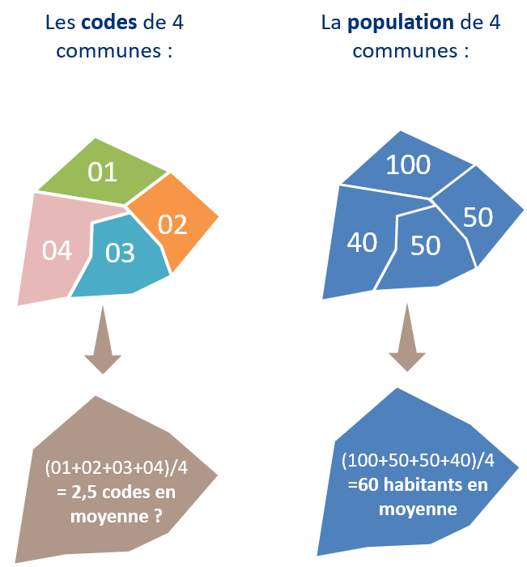

### Les sous types de données qualitatives

Les données qualitatives peuvent avoir d'autres propriétés, importantes en cartographie et en statistique

##### Qualitatif nominal

contient une notion de différence, aucun ordre - Codes départementaux - Des prénoms - Des numéros étudiants

##### Qualitatif ordinal

contient une notion d'ordre sans être mesurable - Une classification : grand > moyen > petit

##### Qualitatif discret

il y a moins de modalités que d'éléments. - Le statut des hôpitaux : CHU, CHR, CH (3 statuts, 6 000 hôpitaux) - Le statut des communes : Capitale, préfecture, sous préfecture

##### Qualitatif exhaustif

il y a autant de modalités que d'éléments - Le nom des pays, des régions - Un code

### Les sous types de données quantitatives

Les données **quantitatives** peuvent aussi avoir d'autres propriétés, toutes aussi importantes en cartographie et en statistique

##### Quantitatif de stock

une quantité brute, un effectif. - La population - Une production en tonne

##### Quantitatif de taux

un rapport, un indice. - La densité de population - Le taux de chômage - L'IDH

### Stock ou taux ?

Il est important de pouvoir justifier le type de données :

[figure not shown]

### Les sous types de données quantitatives

##### Quantitatif repérable

le zéro est conventionnel - L'altitude

##### Quantitatif mesurable

le zéro signifie l'absence concrète - Le taux de chômage - La population

##### Quantitatif discret

une variable discrète a un nombre fini ou dénombrable de valeurs possibles. Elles sont distinctes et séparées : - Le nombre d'étudiants dans cette salle - Les pointures de chaussures

##### Quantitatif continu

il y a un nombre illimité de valeurs. Entre deux valeurs distinctes, il y a toujours une valeur intermédiaire possible : - Le taux de chômage - La vitesse du vent

On peut transformer une donnée continue en donnée discrète en classant les valeurs dans des classes → discrétisation

### En résumé

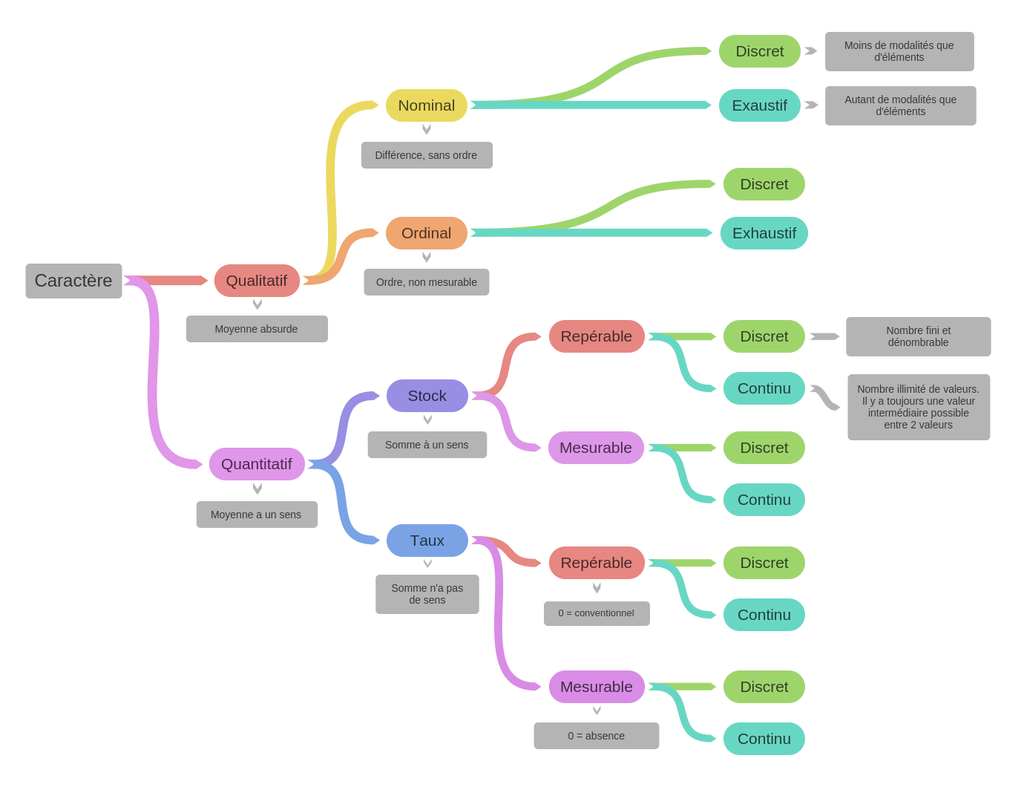

### 2- Les différents types de tableaux

### Rappels

Il existe de nombreux type de tableaux en statistique. Leur forme peut dépendre entre autre:

- Du type de données en amont (comment ont-elles été recueillies ?)
- De la manière dont vous souhaitez analyser vos données (regroupements ?)
- La manière de mettre en forme les tableaux et les variables est un métier à part dans l'entreprise (data manager)

### Tableau élémentaire de données

C'est le cas le plus courant. Il décrit un ensemble d'éléments (lignes du tableau) à l'aide d'un ensemble de caractères (colonnes du tableau).

- La première colonne est généralement réservée à un caractère servant d'identifiant.
- On note *i* un élément quelconque du tableau et *Xi* la " modalité prise par l'élément *i* pour le caractère *X*. "
- En géographie on parlera de **tableau d'information géographique**

| Etudiant | Groupe | UFR |
| --- | --- | --- |
| A | 1 | GEO |
| B | 1 | GEO |
| C | 2 | GEO |
| D | 2 | HIST |
| E | 3 | HIST |
| F | 3 | GEO |
| G | 3 | HIST |

### Tableau de contingence

C'est un cas particulier de tableau élémentaire :

- les lignes et les colonnes jouent un rôle symétrique
- le contenu des cases correspond à des effectifs qui peuvent être sommés en ligne et en colonne.
- On peut parfois calculer des moyennes ou tout autre indicateur statistique si les données le permettent

Tout tableau de contingence est le résultat de la transformation d'un tableau élémentaire constitués de deux caractères discrets X et Y décrivant le même ensemble E

Le nombre de ligne d'un tableau de contingence (k) correspond au nombre de modalités du premier caractère discret (X) et le nombre de colonnes (p) correspond au nombre de modalités du second caractère discret (Y)

L'effectif d'une case, noté Nij, correspond au " nombre d'éléments du tableau élémentaire E qui prennent simultanément la modalité i de X et la modalité j de Y ".

### Tableau de contingence

**Tableau élémentaire de données**

**Transformé en tableau de contingence**

| Etudiant | Groupe | UFR |
| --- | --- | --- |
| A | 1 | GEO |
| B | 1 | GEO |
| C | 2 | GEO |
| D | 2 | HIST |
| E | 3 | HIST |
| F | 3 | GEO |
| G | 3 | HIST |

| UFR x Grp | GEO | HIST | Total |
| --- | --- | --- | --- |
| 1 | 2 | 0 | 2 |
| 2 | 1 | 1 | 2 |
| 3 | 1 | 2 | 3 |
| **Total** | **4** | **3** | **7** |

### Tableau disjonctif complet

C'est le résultat de l'éclatement d'un tableau élémentaire contenant des modalités

- Les variables sont codées en 0 ou 1 pour l'absence/présence d'un caractère
- On l'utilise pour certaines analyses spécifiques (analyses factorielles)
- Ils sont de retour en grâce avec le machine learning

**Tableau élémentaire de données**

**Transformé en tableau disjonctif complet**

| Etudiant | Groupe | UFR |
| --- | --- | --- |
| A | 1 | GEO |
| B | 1 | GEO |
| C | 2 | GEO |
| D | 2 | HIST |
| E | 3 | HIST |
| F | 3 | GEO |
| G | 3 | HIST |

| Etudiant | groupe.1 | groupe.2 | groupe.3 | UFR.GEO | UFR.HIST |
| --- | --- | --- | --- | --- | --- |
| A | 1 | 0 | 0 | 1 | 0 |
| B | 1 | 0 | 0 | 1 | 0 |
| C | 0 | 1 | 0 | 1 | 0 |
| D | 0 | 1 | 0 | 0 | 1 |
| E | 0 | 0 | 1 | 0 | 1 |
| F | 0 | 0 | 1 | 1 | 0 |
| G | 0 | 0 | 1 | 0 | 1 |

### Tableau d'échanges

On parle aussi de matrice de flux

- Il contient des individus géographiques en ligne et en colonne, qui peuvent ou non être identiques
- Un tableau ne peut représenter qu'un seul caractère, par exemple les flux de population entre les individus
- Si le tableau d'échanges n'est pas symétrique, il se lit de la ligne vers la colonne

| Aéroports | Paris | Berlin | Londres |
| --- | --- | --- | --- |
| Paris | - | 15 | 5 |
| Berlin | 10 | - | 20 |
| Londres | 5 | 10 | - |

### Conclusion

### Concepts-clés

Les géographes utilisent de **l'information géographique**, localisable dans l'espace.

- Il existe un vocabulaire propre aux données statistiques, qu'il est nécessaire de connaître.
- Les données peuvent être regroupées selon plusieurs **propriétés**
- Qu'il faut maîtriser, car les règles de la sémiologie graphique et les outils statistiques en **dépendent** !

Plusieurs types de tableaux existent et il est nécessaire de les reconnaître

- Les tableaux élémentaires de données sont les plus courants, avec en ligne les individus et en colonnes leurs caractères
- Les tableaux de contingence permettent de croiser des caractères
- Les tableaux d'échanges sont très appréciées des géographes